# Lending Club Exploratory Data Analysis

Lending Club is an online lending service that allows borrowers to connect with investors through a marketplace in a service known as peer-to-peer lending. It’s a form of lending that’s known to often be cheaper than banks. The dataset that will be explored in this exploratory data analysis investigation is one that contains loan data for almost 900 000 loans handled by Lending Club between 2007 and 2015. It includes observations on over 70 variables including loan description, interest rate, loan status, and many more.

Through this analysis, we hope to gain a better understanding of:

1. What types of loans Lending Club are making?
2. What types of people take out these loans?
3. How does Lending Club create loans that are favourable for investors?

We notice right off the bat that this dataset is very large. We cannot possibly examine every variable in this analysis. Returning to our primary aims, we can narrow down the list of variables to examine.

It was also discovered that several key variables listed in the dataset documentation are missing from the actual data. Most importantly, no FICO credit information is available for any of the loans, taking away a key factor in the money lending process.

```r
working <- select(loan, addr_state, annual_inc, purpose, dti, grade, sub_grade,
                  issue_d, emp_title, home_ownership, loan_amnt, member_id,
                  term, int_rate, installment, delinq_2yrs, loan_status)

working$grade <- factor(working$grade,
                        c("A", "B", "C", "D", "E", "F", "G"), ordered=TRUE)

str(working)
```

```
## 'data.frame':    887379 obs. of  16 variables:
##  $ addr_state    : Factor w/ 51 levels "AK","AL","AR",..: 4 11 15 5 38 4 28 5 5 44 ...
##  $ annual_inc    : num  24000 30000 12252 49200 80000 ...
##  $ purpose       : Factor w/ 14 levels "car","credit_card",..: 2 1 12 10 10 14 3 1 12 10 ...
##  $ dti           : num  27.65 1 8.72 20 17.94 ...
##  $ grade         : Ord.factor w/ 7 levels "A"<"B"<"C"<"D"<..: 2 3 3 3 2 1 3 5 6 2 ...
##  $ sub_grade     : Factor w/ 35 levels "A1","A2","A3",..: 7 14 15 11 10 4 15 21 27 10 ...
##  $ issue_d       : Factor w/ 103 levels "Apr-2008","Apr-2009",..: 22 22 22 22 22 22 22 22 22 22 ...
##  $ emp_title     : Factor w/ 299273 levels "","'Property Manager",..: 1 224800 1 9376 282199 285977 246848 171062 1 256905 ...
##  $ home_ownership: Factor w/ 6 levels "ANY","MORTGAGE",..: 6 6 6 6 6 6 6 6 5 6 ...
##  $ loan_amnt     : num  5000 2500 2400 10000 3000 ...
##  $ member_id     : int  1296599 1314167 1313524 1277178 1311748 1311441 1304742 1288686 1306957 1306721 ...
##  $ term          : Factor w/ 2 levels " 36 months"," 60 months": 1 2 1 1 2 1 2 1 2 2 ...
##  $ int_rate      : num  10.6 15.3 16 13.5 12.7 ...
##  $ installment   : num  162.9 59.8 84.3 339.3 67.8 ...
##  $ delinq_2yrs   : num  0 0 0 0 0 0 0 0 0 0 ...
##  $ loan_status   : Factor w/ 10 levels "Charged Off",..: 6 1 6 6 2 6 2 6 1 1 ...
```

# Univariate Plots and Analysis

We will start by examining the number of loans given over the duration of the data recorded in the dataset.

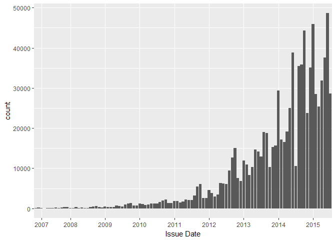

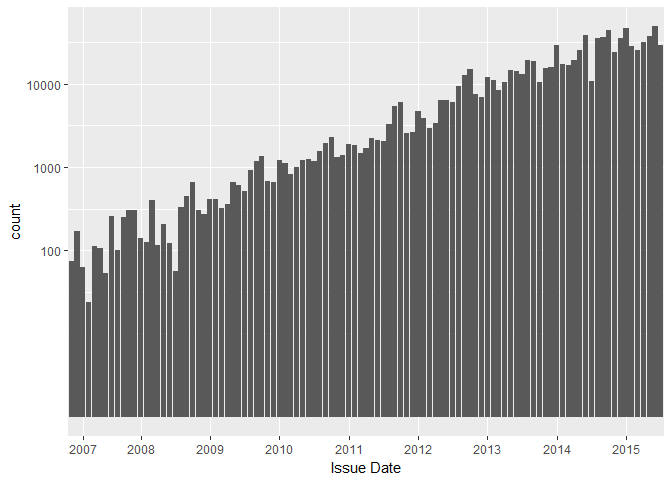

The number of loans given out increases steadily as the years pass. Looking at the second plot with a logarithmic y-axis, we can see this growth as an almost linear increase, indicating the number of loans made through Lending Club is increasing exponentially. We can also see that the growth is not constant. There are many months were there are large spikes and other where there are large dips. To see if there is any pattern in these spikes, we will look at the numbers behind the visualization.

```
## [1] Yearly totals:
```

```
## date_sorted$issue_year
##   2007   2008   2009   2010   2011   2012   2013   2014   2015
##    603   2393   5281  12537  21721  53367 134755 235628 421094
```

```
## [1] Monthly averages:
```

```
## date_sorted$issue_month
##       Jan       Feb       Mar       Apr       May       Jun       Jul
##  7853.125  6468.500  7012.750  8776.750  8491.125  7097.111 10611.000
##       Aug       Sep       Oct       Nov       Dec
##  8502.444  6910.444 12441.222  9786.778  8935.556
```

As expected, the number of loans made is increasing rapidly throughout the years. In the 8 years between 2007 and 2015, the number of loans made through Lending Club increased by almost 700 times.

Now the monthly average figures is where it gets interesting. General experience would tell us that most people would probably take out loans most often around the holiday season when many big purchases are made. However, there doesn’t appear to be any real, explainable trend in the monthly average data with the two highest monthly averages occurring in October and July and the lowest in February and September.

Now that we know how many loans Lending Club are making, and when they are made, we should learn about what *type* of loans they are facilitating. All loans made are graded for stability and risk by lenders using factors like credit history, collateral, likelihood of repayment, etc. We can see the distribution of the grades of the loans below.

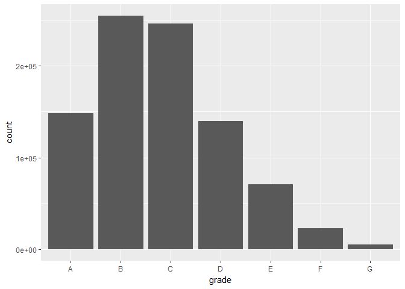

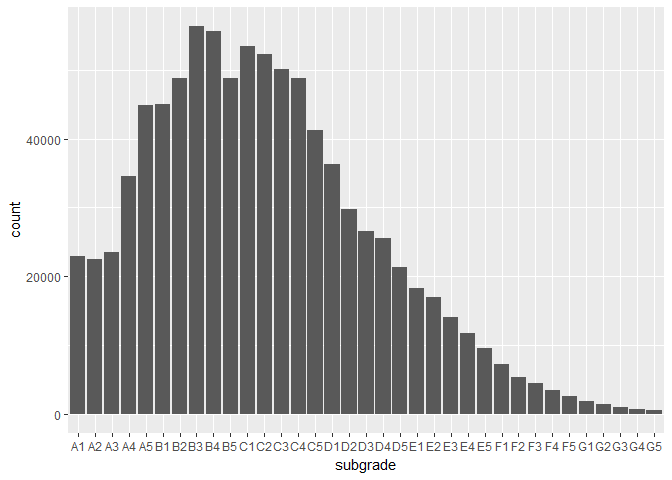

As we can see, the distribution for both grade and subgrade is right-skewed with most of the loans being of grade B or C. Looking at the more detailed subgrade classifications, we see the same general shape. Very high grade loans (A1, A2, A3) are not quite so common and the tail also tapers off quickly with very few loans of grade F and G. This shows that most investors are more likely to take on safer loans rather than make perhaps more money with more risky options.

With this in mind, what is the risk like to investors? How many of Lending Clubs loans are unsuccessful?

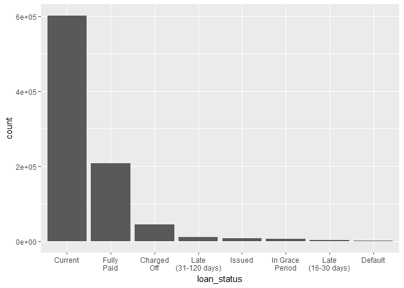

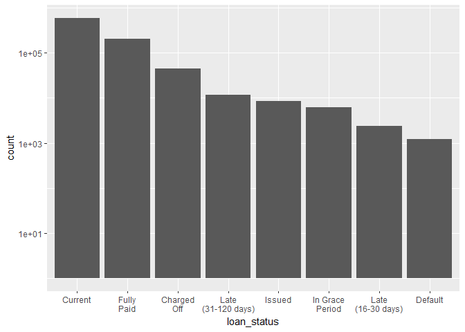

```
##                                         Charged Off
##                                               45248
##                                             Current
##                                              601779
##                                             Default
##                                                1219
## Does not meet the credit policy. Status:Charged Off
##                                                 761
##  Does not meet the credit policy. Status:Fully Paid
##                                                1988
##                                          Fully Paid
##                                              207723
##                                     In Grace Period
##                                                6253
##                                              Issued
##                                                8460
##                                   Late (16-30 days)
##                                                2357
##                                  Late (31-120 days)
##                                               11591
```

The distribution shows that the vast majority (70%) of Lending Club loans are currently in progress and up to date on all payments. The numbers then drop off steeply leading into a very long tail that has been adjusted using a log(10) y-axis in the second plot.

Additionally, to further understand the investment potential on Lending Club loans, we should look at the potential returns for the investors. Lending Club assigns an interest rate to each loan based on loan grade and borrower credit history.

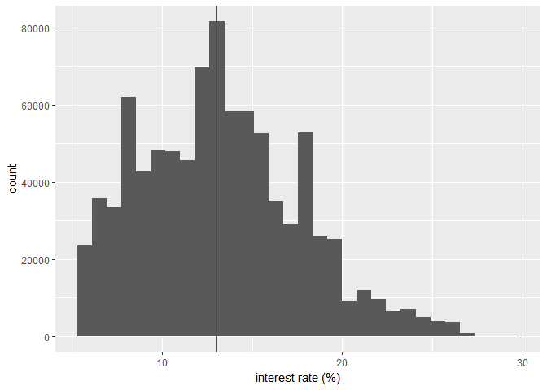

```
##    Min. 1st Qu.  Median    Mean 3rd Qu.    Max.
##    5.32    9.99   12.99   13.25   16.20   28.99
```

Now let’s look at the actual amount of money loaned out through Lending Club services.

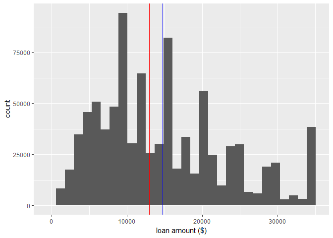

```
##    Min. 1st Qu.  Median    Mean 3rd Qu.    Max.
##     500    8000   13000   14760   20000   35000
```

With these loan amounts in mind, we will now examine the annual income of loan applicants.

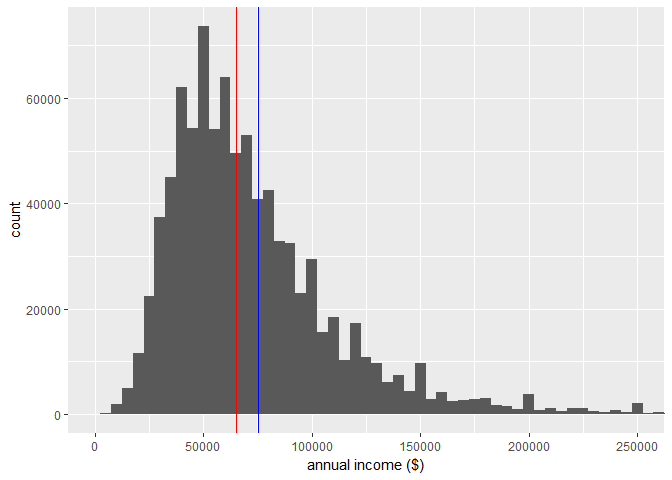

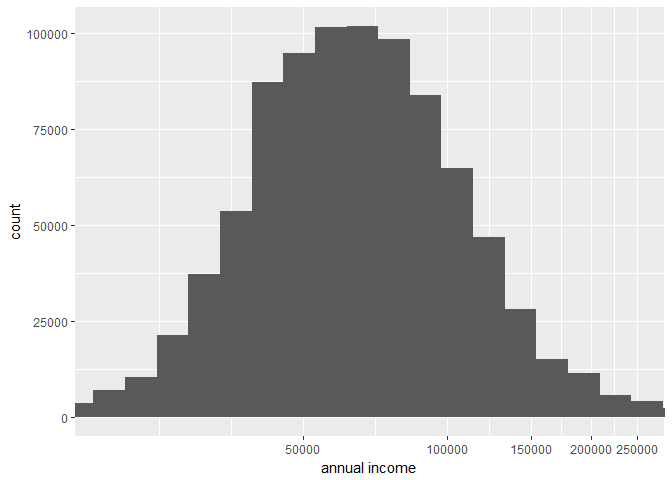

```
##    Min. 1st Qu.  Median    Mean 3rd Qu.    Max.    NA's
##       0   45000   65000   75030   90000 9500000       4
```

Once again, the red line represents the median and the blue, the mean. As we can see from these plots, the distribution for the annual income is right- skewed with a long tail and extreme outliers (a maximum value of $9 500 000). Transformed with a log(10) x-axis, the distribution appears to be somewhat normal. This means that there appear to be individuals with very high annual incomes (into the high 6-figures and beyond) that are applying for relatively small loans (up to a maximum of $35 000). We should now look at who exactly the people taking out these loans are.

```r
# Select only data from after September 2013
after_sep_2013 <- subset(working, !is.na(emp_title)) %>%
  select(emp_title, issue_month, issue_year) %>%
  filter((issue_year > 2013) | (issue_year == 2013 &
                                (issue_month %in% c("Oct", "Nov", "Dec")))) %>%
  group_by(emp_title) %>%
  summarise(n = n()) %>%
  arrange(desc(n))
```

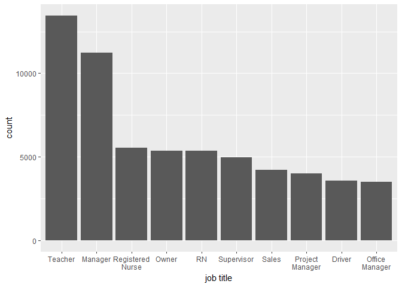

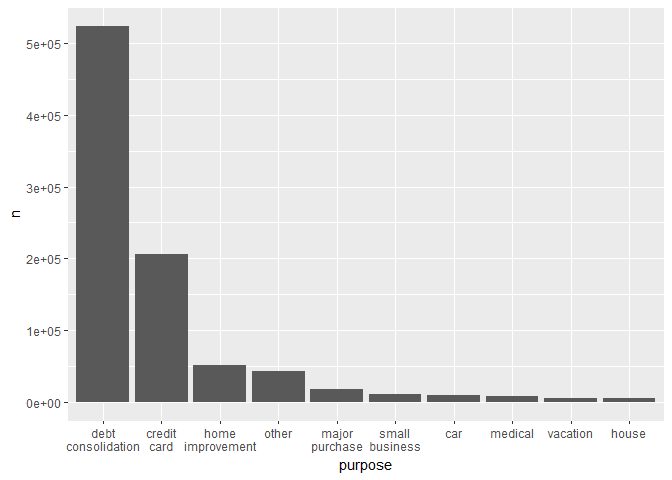

It would seem that the vast majority of loan applicants applied for the purpose of debt consolidation, with a smaller, but still significant number for credit card debts. Nothing here is really out of the ordinary or unexpected. The three most common purposes are also the same ones advertised right on the front page of Lending Club’s website and are probably the most common sources of debt in the US.

# Multivariate Plots and Analysis

While looking at the variables in the dataset individually has given us important insights into the data, we can’t really go about understanding what the data can really tell us without looking at variables in relation to each other.

We’ll start by examining the geography of borrowers. (It’s expected that there won’t be much learned about the data through this, but I wanted a chance to explore the mapping packages offered in R.)

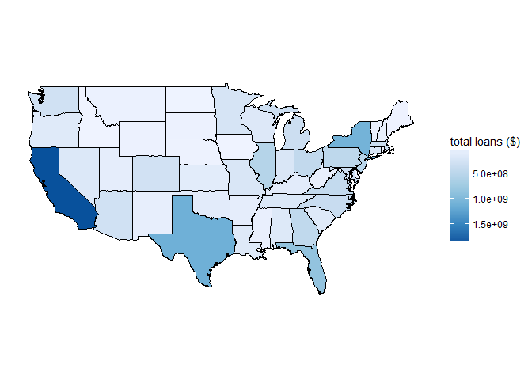

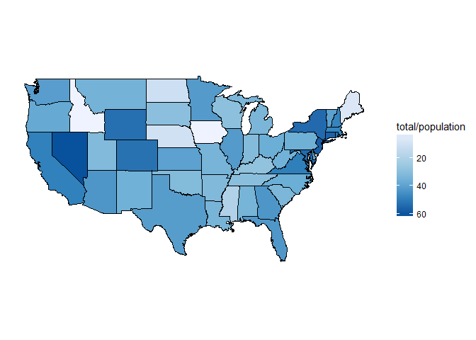

It seems from this map that the highest loan amounts come from the states of California, New York, and Texas. This is to be expected as these are also the three most populous US states. After adjusting the map to show loan amounts per person, there appears to be no real relationship between states and Lending Club usage.

As a public company with shareholders to please, one of Lending Club’s primary objectives is to be profitable. Part of this revolves around creating the most favourable conditions for their investors to make returns. In this part of the investigation, we would like to determine how Lending Club assesses and sets the conditions of a loan (interest rate, grade, term, approved loan amount, etc.).

We start by noting that Lending Club loans are offered in two different lengths of terms, 36 months or 60 months. Let’s examine these two types of loans and how they differ.

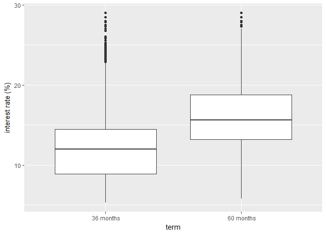

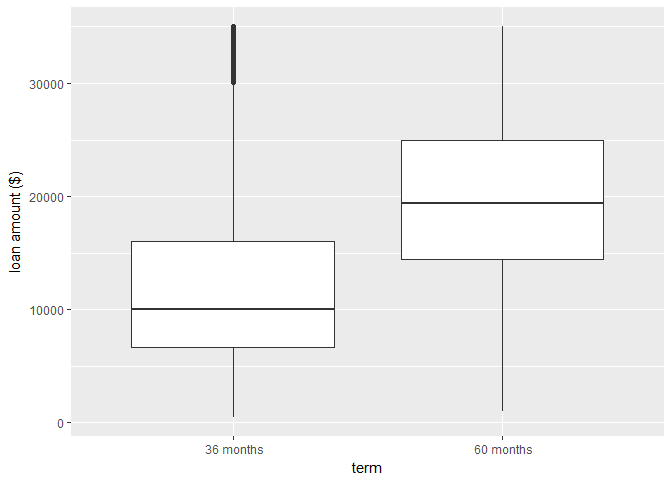

We see immediately that loans with 60-month terms have on average almost 4% higher interest than their shorter term counterparts. Continuing to plot versus term, we find also that the longer terms are associated with significantly larger loan amounts as well. The median loan amount for 60 months is almost double the amount taken in 36-month loans.

Let’s look next at the grade classification of these loans. How does Lending Club rate the risk of loans of differing lengths? To do this, we need to create a stacked bar plot showing the proportion of loans of each grade that are of each loan length. We start by creating a function that will calculate the proportion that each term-length of loan takes up in each grade. This function can then be used later on to create other stacked proportion bars.

```r
# Function to determine percentage breakdowns of var1 within each
# value of var2

percent_breakdown <- function(data, var1, var2) {

  sum_by <- data %>%
    select_(var1, var2) %>%
    group_by_(var2, var1) %>%
    summarise(count = n())

  count_by <- by(sum_by$count, sum_by[[var2]], sum)

  count_by<- sapply(count_by, I)

  count_by <- data.frame(levels(sum_by[[var2]]), count_by)

  colnames(count_by) <- c(var2, "total")

  breakdown <- merge(sum_by, count_by, by = var2)
  breakdown$percentage <- breakdown$count / breakdown$total

  return(breakdown)
}
```

With the percentage breakdowns calculated, we can now plot.

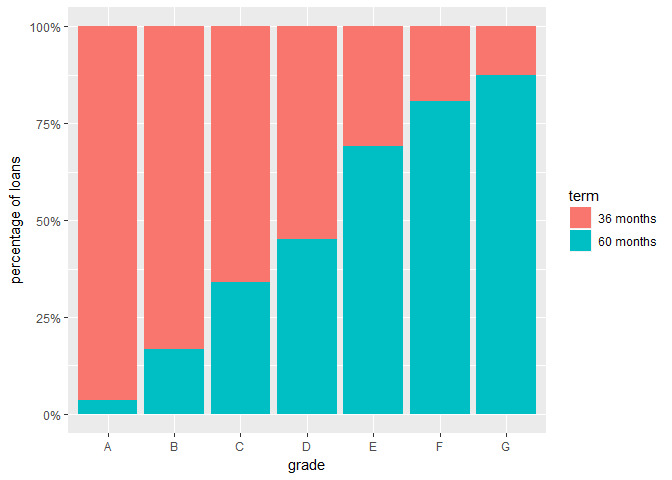

This plot makes it clear that the lower the grade, the higher the proportion of loans that are of longer length. The difference is extremely evident with only 3.5% of grade A loans having a 60-month term but 87.5% of grade G loans having the same term.

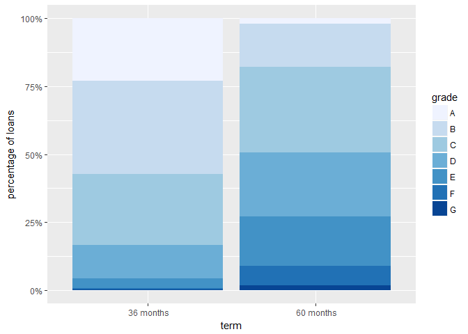

Reversing the breakdown and instead plotting the percentage breakdown of each length of term by grade reveals similar information. 36-month loans are composed mostly of grade A, B, and C loans (comprising a total 83%). Moving to 60-month loans, the number of A and B grade loans drops off sharply (down 67%) while the proportion of grade D, E, F, and G loans increases.

It is clear that, in general, Lending Club loans with 60-month terms are classified as riskier with a lower grade. This is likely caused by both the longer length of the loan and the much higher average value of the longer loans.

Is it really true though? Are 60-month loans more likely than their shorter counterparts to default or be charged off?

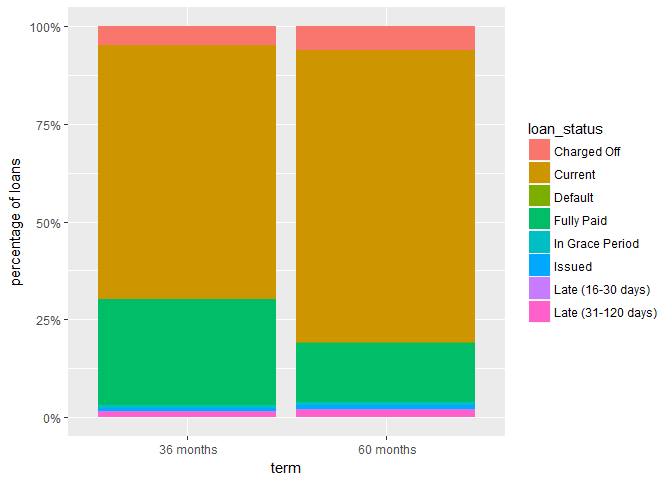

It would seem that while Lending Club generally rates longer term loans as riskier with higher interest rates, from the current outcomes, it doesn’t appear as though 60-month loans are inherently more risky to investors in terms of proportion of loans that default or are charged off.

In addition to the length of the term, let’s examine what other factors go into the determination of a loan’s conditions. Let’s start by looking at what kind of factors could affect a particular loan’s interest rate.

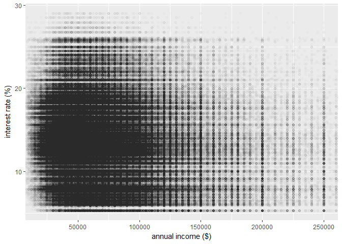

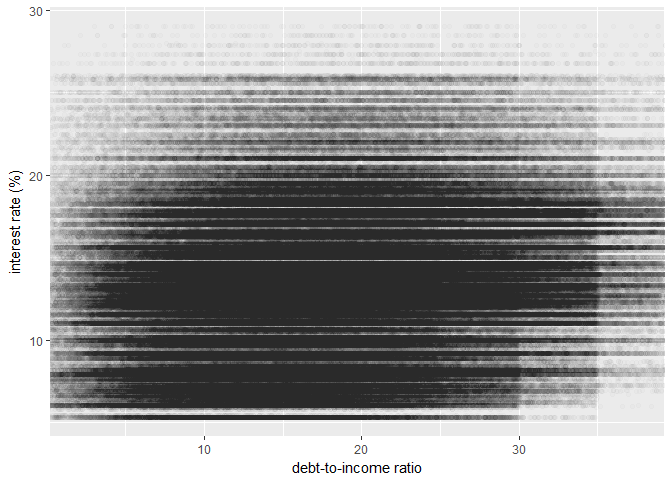

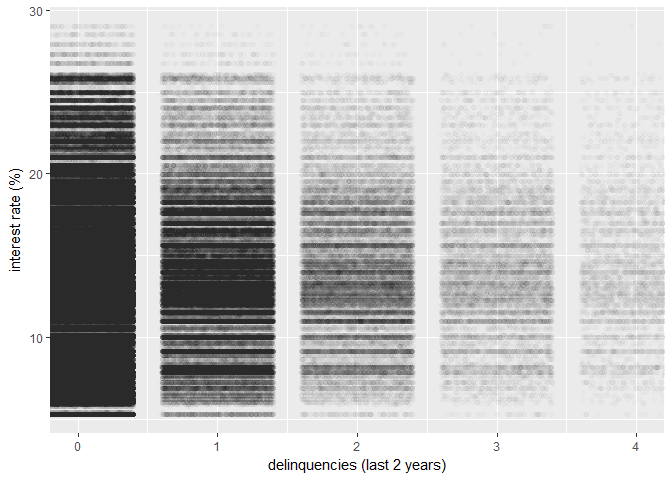

These plots seem to show that none of the three indicators I believed would be telling about how interest rates are determined have any relationship with the interest rate. Both the interest vs. annual income and the interest vs. dti (debt-to-income ratio) graphs show a distinct lack of any real relation. With the interest rates vs. deliquencies figure, we see that while there are much fewer loans with higher and higher numbers of delinquencies, the same basic bands in the interest rates exist between all of the delinquency categories.

This is an incredibly surprising finding as I believed these three to be among the most important ways of determining whether or not a loan would be paid back. What else other than how much someone makes, how much they borrow, and how many times they’ve previously failed to repay a loan could indicate the risk of a borrower not paying back a loan?

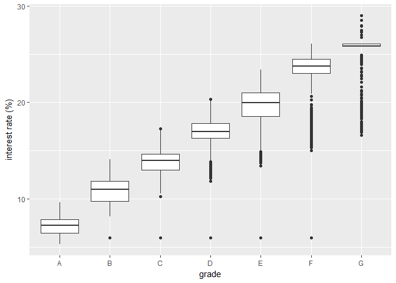

This plot shows us that the interest rate seems to be directly pegged to the grade rating of the loan. There is very little overlap between the ranges of interest rates for each grade. This suspicion is confirmed by Lending Club’s website which indicates that interest rates are calculated from the loan grade classification of each loan (https://www.lendingclub.com/foliofn/rateDetail.action).

The same Lending Club site hints at factors that are taken into account in the loan classification process. It appears the some of the factors examined earlier (namely deliquency history and debt-to-income ratio) are taken into account in classifying the grade of each loan. With that in mind, perhaps we should look at those same factors and how they vary between each grade.

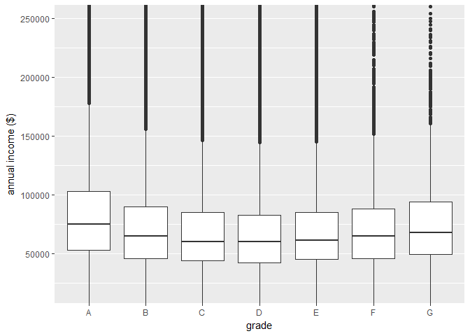

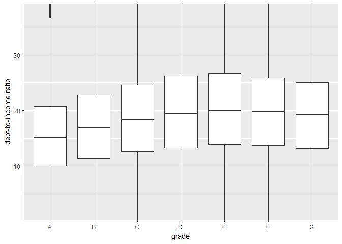

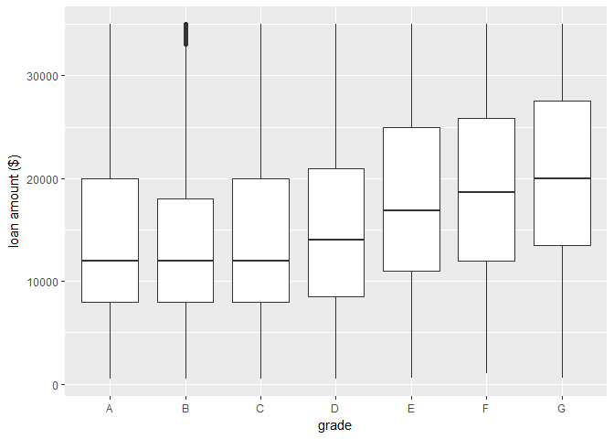

There does appear to be a dip in annual income as the grades lower, however they rise again approaching the lowest grades (F and G). There is also a slightly higher debt-to-income ratio for lower grade loans, however once again, they dip at grades F and G. More telling however is the loan amount boxplot. Larger loans generally appear to be given a lower grade, with the median loan amount for a grade G loan being almost $8000 higher than that of a grade A, B, or C loan.

We once again seem to be at a dead end. Loan amount can’t possibly be the only factor in determining the risk of a loan and the other variables show only a slight relationship with loan grade. It would appear that even if these are the factors taken into account in the loan-making process, they must not play a significant factor as there is very little relationship to be seen between their values and the actual risk rating.

What about the actual classification though? How accurate is the grade rating at predicting the success rate of the loan?

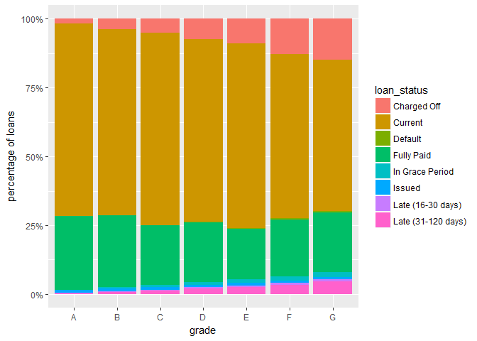

It seems pretty apparent that grade is in fact at least somewhat indicative of a loan’s risk. We can see the very steady increase in proportion of loans charged off as the grade lowers along with a similar increase in the proportion of late loans. While we so far haven’t identified what exactly goes into Lending Club’s rating of loans, it does appear to do a good job of accurately rating the risk of loans.

Let’s turn our attention now away from risk assessment of the loans and onto what these loans are used for.

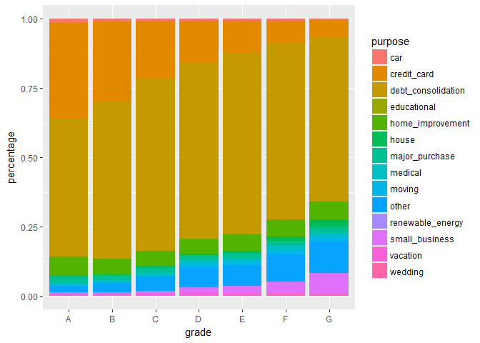

There are a few standout relationships we can draw from this figure. We can see that the higher grade loans have a higher proportion of credit card loans and a lower proportion of loans classified under “small business” and “other”.

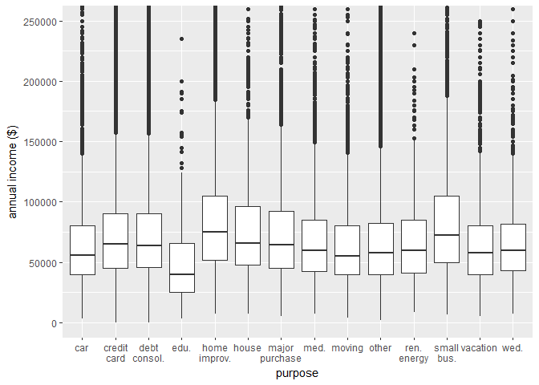

The most interesting revelation to come out of this plot is that loans given for the declared purpose of education have a median borrower income almost $25 000 lower than average. This makes sense as these are likely students, recently graduated, looking for a low-interest way of consolidating student loans. On the other hand, we can see that loans made for the purpose of small business and home improvement have a slightly above average annual income, one again reflective of the nature of the purpose of these loans.

# Final Plots and Summary

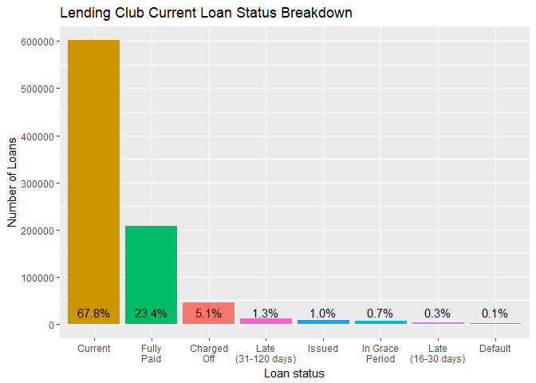

The above figure shows the current spread of loan statuses at Lending Club. Most loans seem to be current and up-to-date on payments, followed by complete and fully paid loans. Around 1/20 of loans are charged off.

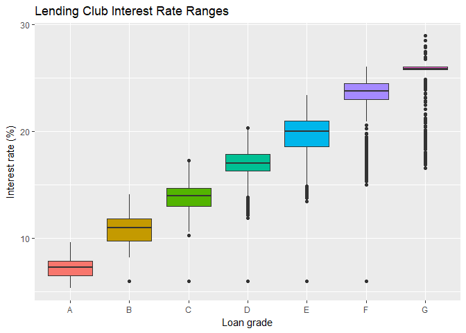

It appears that Lending Club interest rates are assigned based upon the loan grade classification given to each loan.

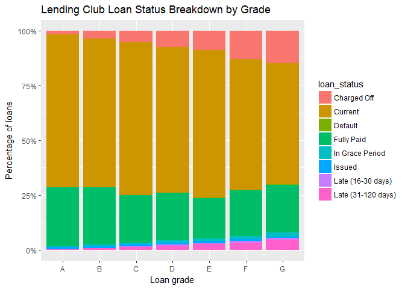

Lower grade loans are more commonly charged off or late than higher grade ones.

# Reflection

We’ve examined the characteristics of Lending Club’s customer base and the characterics of the loans they facilitate. We’ve looked at the factors that potentially go into the determination and classification of risk for a loan and how those factors correlate with a loan’s status and chance of repayment.

There are however, many answers left to be uncovered and many questions left to be asked. The scale of the dataset is so massive that any such analysis can only focus on a small subset of the available data. Questions that we have been unable to answer in theis exploration, such as what factors really go into the risk assessment and classification of loans, may become evident had more variables been considered (such as total number of credit lines, collateral amounts, etc.). Perhaps we chose the right ones in this exploration.

Additionally, and importantly, a crucial variable to this investigation was missing from the dataset. The documentation indicates that there should be a variable storing the FICO credit score information for each borrower. By all indications – the Lending Club website, how loans are generally given – this is perhaps the most important variable in determining the terms of any loan. Since we found no significant relationship between any of the main factors in determining a loan’s risk and the actual assessment of said risk made by Lending Club, credit score is perhaps the primary assessment factor. Without this variable, our exploration can never be truly complete.